# ISM Honours Information and Knowledge in Organisations Data Analysis Assignment 2: Data Collection and Text Mining

### How they difffer:

#### Over Time:

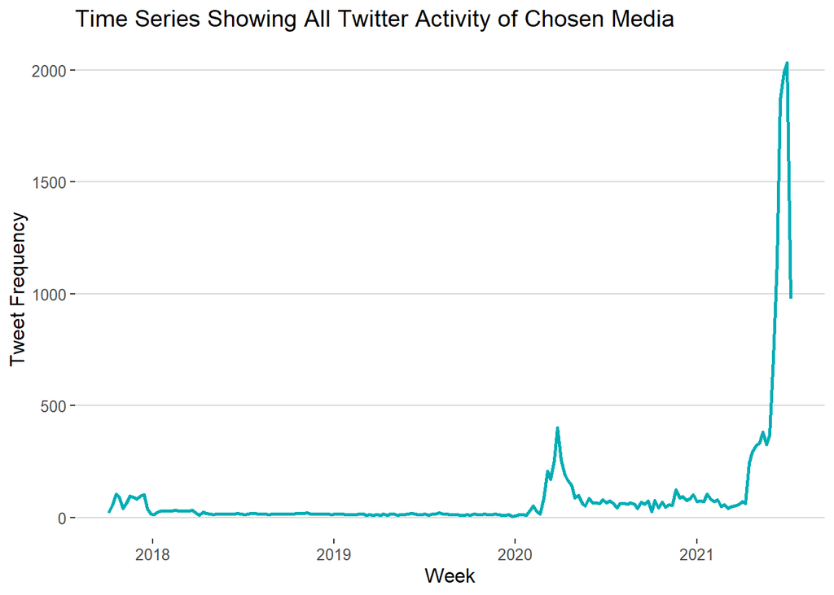

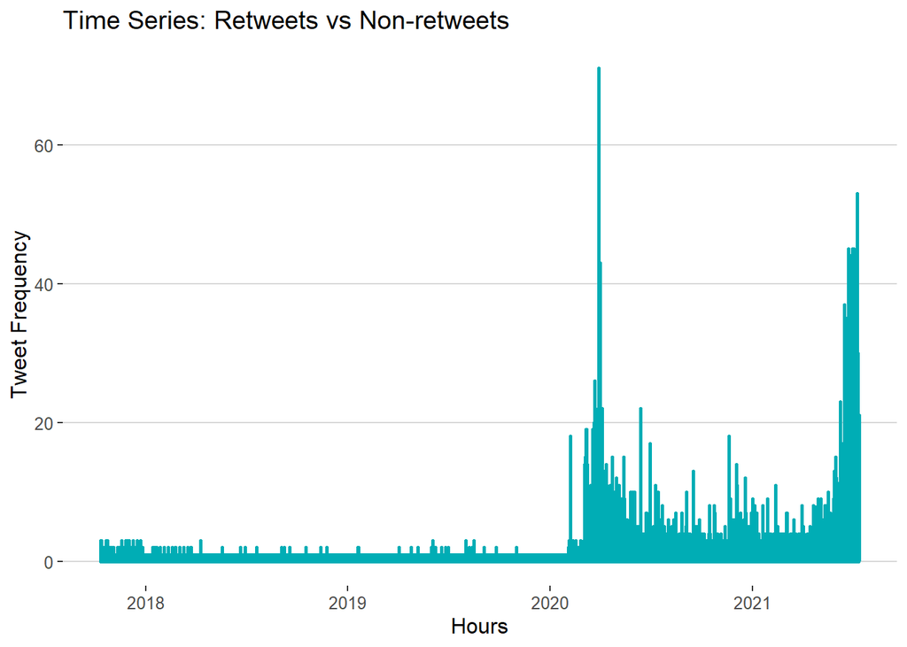

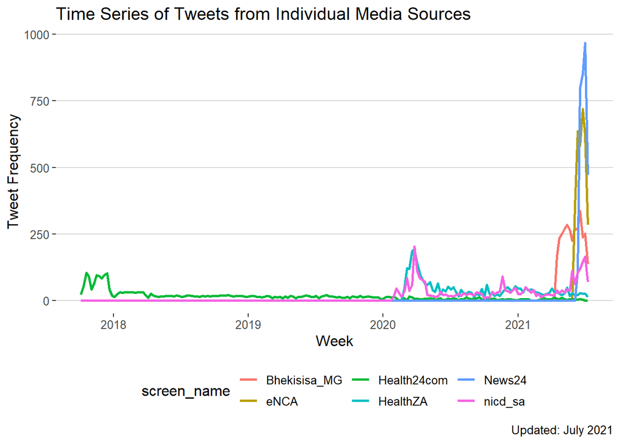

Time series of tweets from individual media sources indicates that there was a stark increase in Twitter activity in June and July of 2021.The most active of these media Twitter accounts is News24.

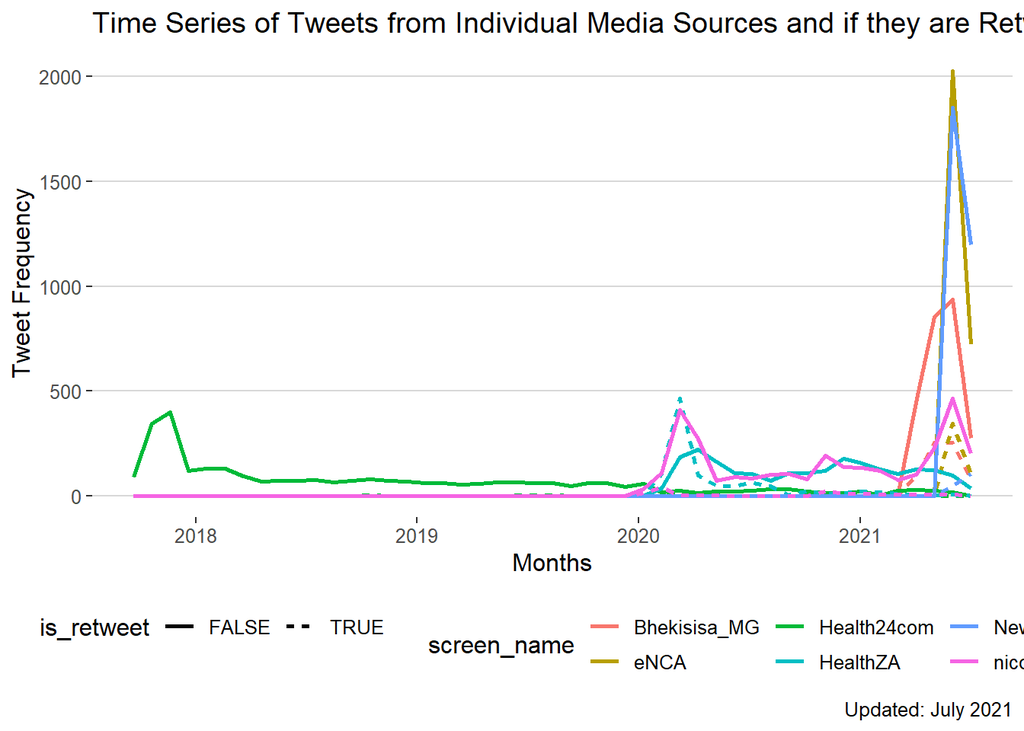

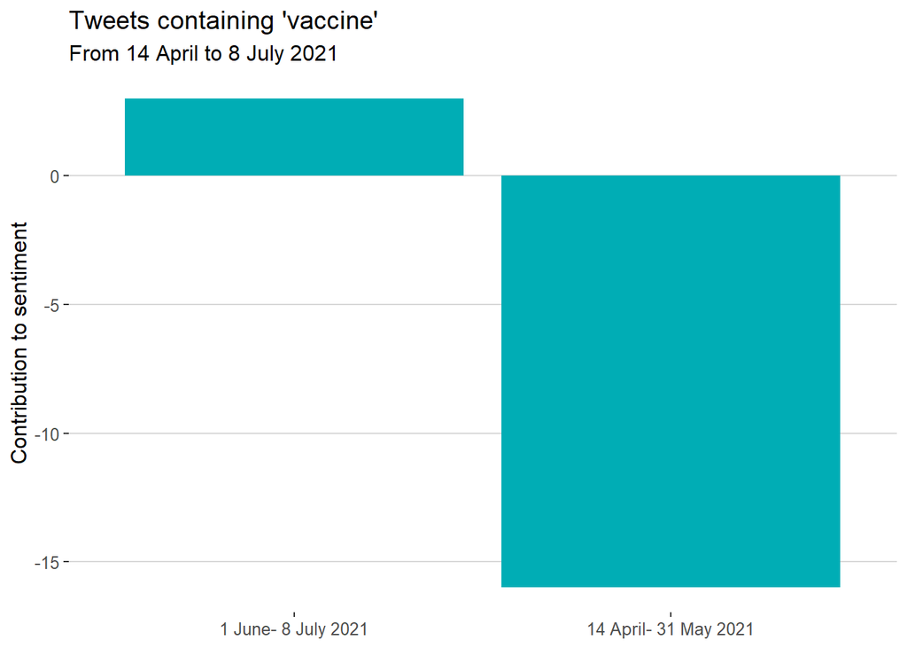

# Additional Requirements:

#### By Media Source:

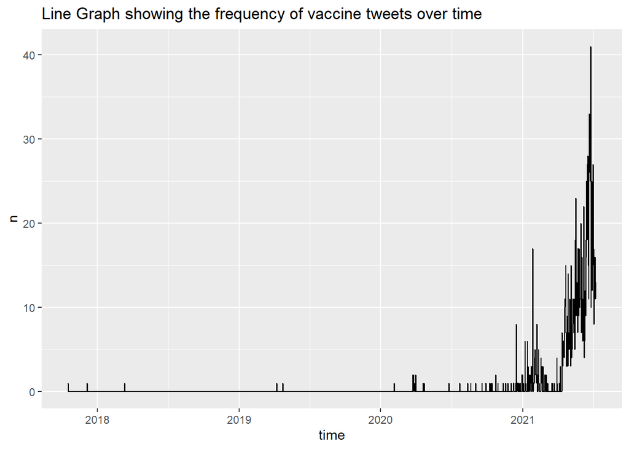

Time series line graph showing the the frequency of vaccine tweets over time indicates the frequency of tweets pertaining to vaccinations in South Africa is sharply increasing.

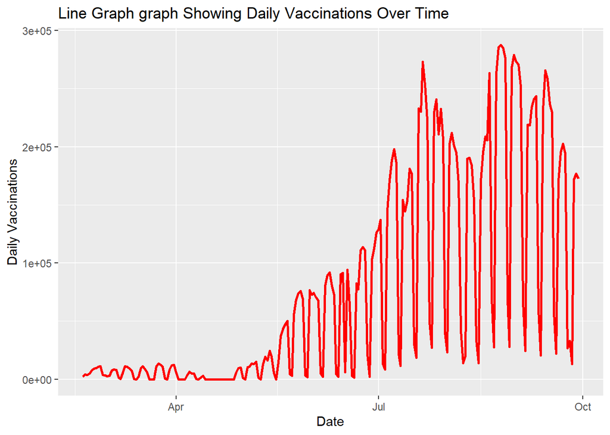

Line graph showing the daily vaccinations over time sharply increasing as more people are permitted to be vaccinated.

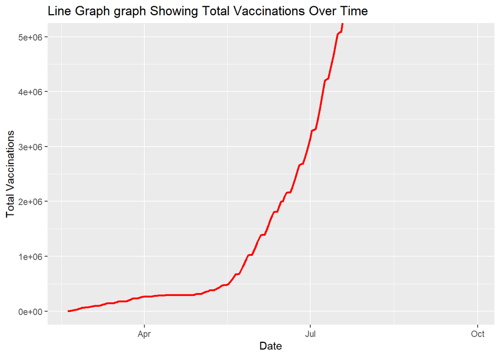

The line graph showing the total vaccinations shows steep increases whenever new age groups are permitted to be vaccinated.

When taking all three charts into account it can be surmised that there is a correlation when observing the more age groups are permitted to be vaccinated in South Africa,the more tweets pertaining to vaccines are made.

# Report Summary:

The visualisations drawn from the text analysis methods used in this report display certain common characteristics from which certain conclusions can be documented. There seems to be a difference in how selected media sources present information regarding COVID-19 and its underlying branches, such as deaths, vaccinations, and tests. Also, the pertaining sentiment and topics of these subjects.

In summation, with regards to the topic modelling section, we were able to determine the highest TF-IDF (Term Frequency-Inverse Document Frequency) words in the six selected media sources, the highest word probabilities for each topic, the top ten media topics according to the beta matrix at topic level 1, as well as the distribution of word probabilities for each topic. ‘covid’ has a notable presence within all these analysis methods.

In regard to the text networks, we were able to identify two clusters or communities within the author-based projection text network and six clusters or communities within the word-based projection text network. From these text networks we were able to derive insight from which word or media sources have a strong similarity with each other.

# Retrospective:

Looking back there are a few points the project group would like to have changed. Firstly, aesthetic enhancements for graph visualizations such as numeric values on top of bar chart bins and better tabular visualizations. Secondly, a greater use of the `Vader` and `sentimentR` packages. Thirdly, more external COVID-19 data that could be collated with Twitter data. Finally, combining the Twitter time series plots with lockdown level and infection wave overlays.